# Tenor Data Challenge

By - Sameer Darekar(sdarekar@iu.edu)

### 1. Warmup metrics

#### 1.1. Aggregate “share rate”: Ratio of shares to searches

We can calculate the share rate by dividing the total number of shares to total number of searches the answer is 0.657 as shown in fig 1

```
select
  (
    (sum (case when eventname = 'share' Then 1 Else 0 End)::decimal)
      /
    (sum (case when eventname = 'textsearch' Then 1 Else 0 End)::decimal)
  ) as ShareRate
from
  ios_events;
```

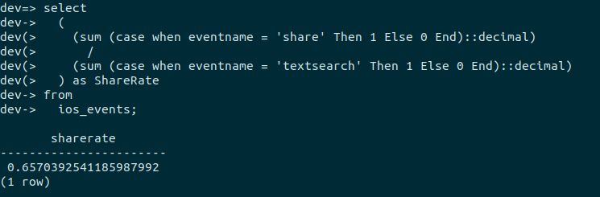

#### 1.2. Compute the share rate for the top 1000 most-searched terms

For calculating this we need to filter the first 1000 most searched tags and use the query above to get the ratio the answer is 0.727

```
select
  (
    (sum(case when eventname = 'share' Then 1 Else 0 End)::decimal)
      /
    (sum(Case When eventname = 'textsearch' Then 1 Else 0 End)::decimal)
  ) as ShareRate
from
  ios_events
where
  tags in (select tags
            from ios_events
            group by tags
            order by count(*) desc  limit 1000)
;
```

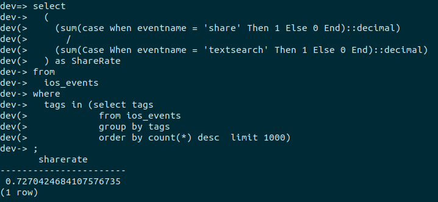

#### 1.3. How many unique search terms are there? What does the distribution look like (consider the count per search term; plot or describe the results)?

Number of Unique search terms is 2729143, which can be calculated by following query

```
select count(distinct(tags)) from ios_events;
```

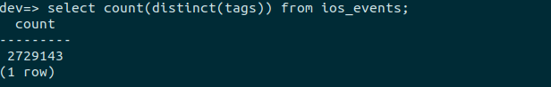

Let us have a look at the distributions of the search terms:  
I organized the data as follows and I found that the blank search term has maximum number of occurrences

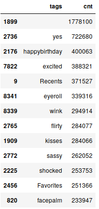

Due to lack of space I have just plotted the top 100 search tags which is shown as follows

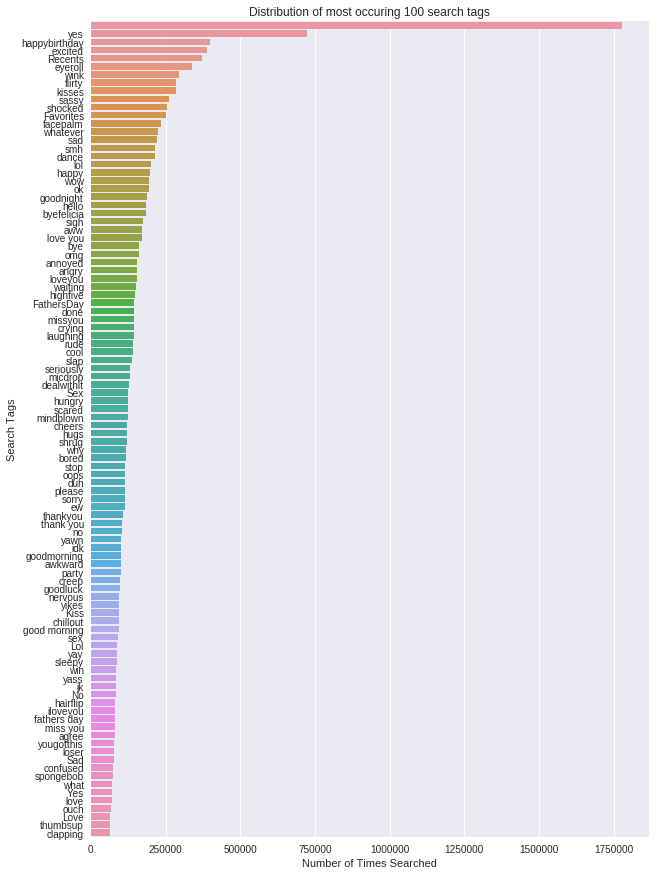

we see that that top tag is blank and has occurred significantly more number of times than any other hence I am ignoring it for a moment to focus on the remaining tags. I have selected the top 500 tags as I feel it give the gist of the whole distribution. We can see that the search tags frequency follows the zipf’s law though not precisely but very closely. The tail of this distribution if we go beyond 500 seem to flatten out.

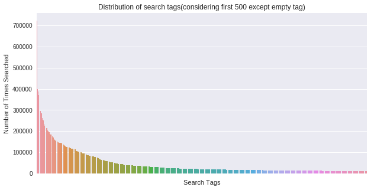

There was one very interesting fact which I found out which can be seen in the graph below the the number of searches from 5 to 8 pm are the highest, If the data is from same timezone(Assumption) we can conclude that people use the gif keyboard more after office hours.

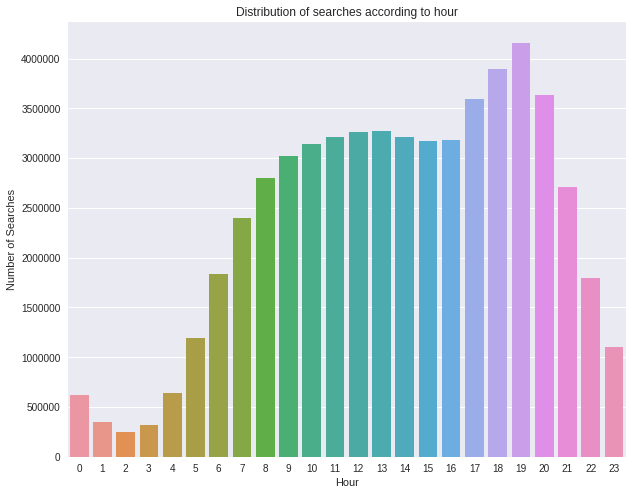

To delve more into the above mentioned fact I selected the top 25 searched tags and plotted a heatmap which is normalized by row such that I just see the peak of each distribution according to time. There are some obvious conclusions which we can make such as people wish good night after 7pm, they wish happy birthday at the start of the day. We also see that the search tag “excited” shows a multi modal distribution with small peaks at around 12 and 7pm. Most of the search tags have peaks around 7 pm which justifies the graph above.

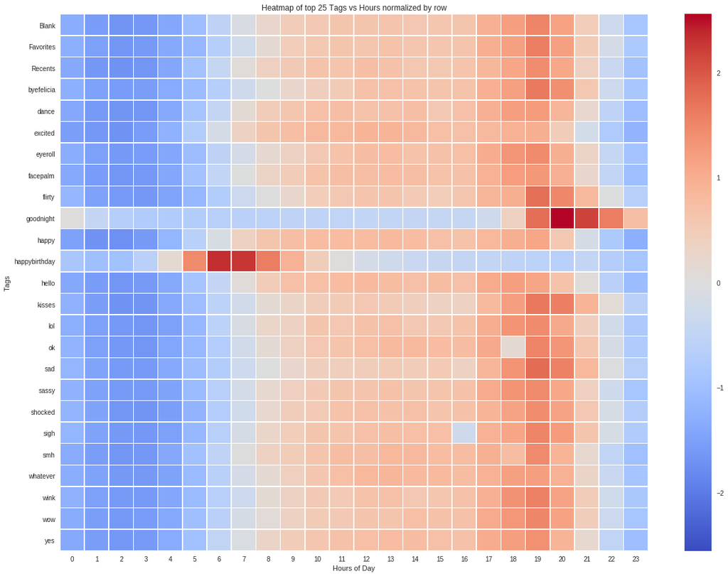

There are many ways in which we can analyse this data as there are multiple other columns in which we can segregate data and get meaningful stories more on that later.

#### 1.4 How many unique gifs are shared? What does the distribution look like?

Number of Unique gifs shared are 481394 which can be calculated by following query

```
select count(distinct(riffid)) from ios_events where eventname = 'share';
```

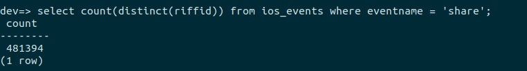

Let us have a look at the distribution of count per GIF shared which looks somewhat similar to what we saw before in distribution of search tags. We can say that there are some GIFs which are most popular.

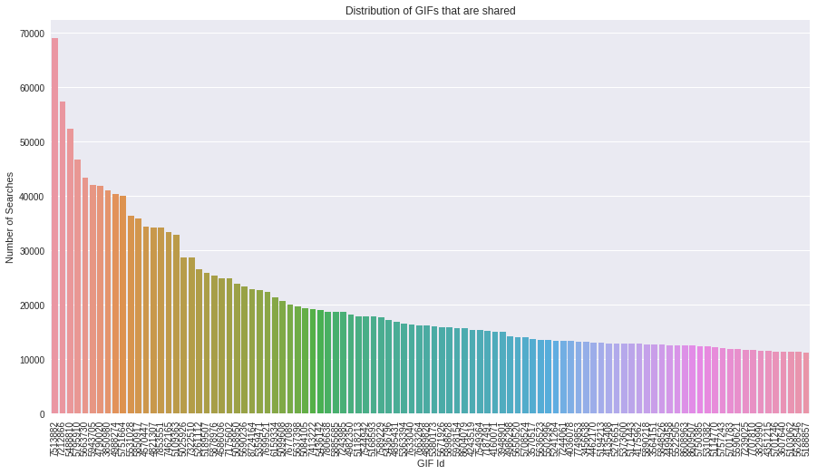

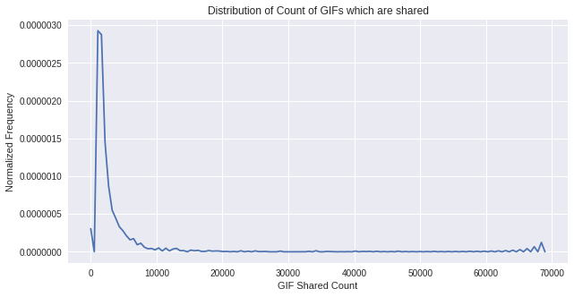

If we had more information(metadata) of the Gifs we could have analysed the temporal pattern regarding the emotion which can be conveyed by gif sharing.

#### 1.5. Other Data Analysis

##### 1.5.1. Analysis of Actions

Lets take some look at the actions which tells about app behavior triggering the search, we see that “qwerty” is the highest among all.

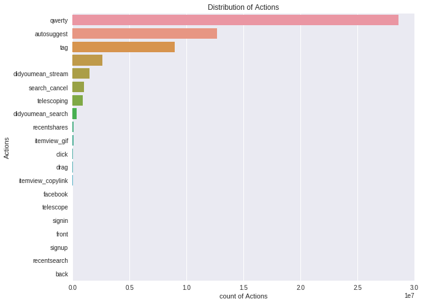

If we take a look at the top 6 actions we see the variability in them over time, if we had some more information about the actions it could have been beneficial to analyse it.

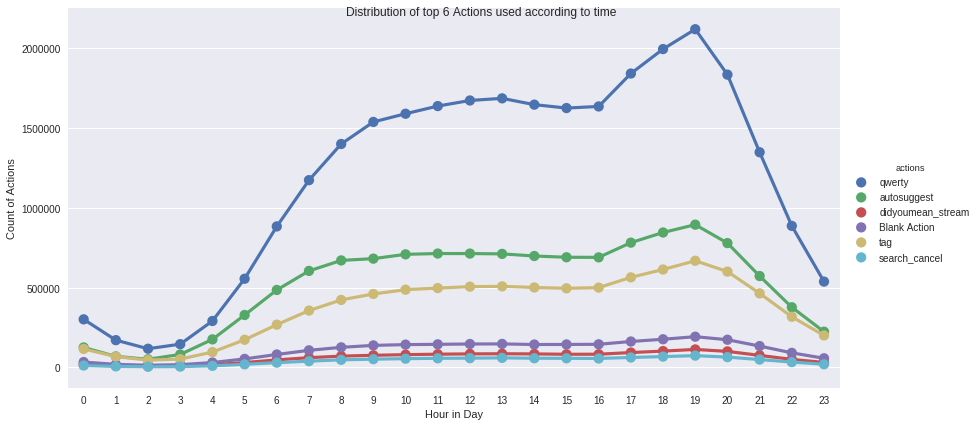

##### 1.5.2. Analysis of Usage Pattern

Lets take a look at the top 25 users who have used the app for the highest number of searches. We see that usage pattern is not uniform accross users. There are some significant patterns in here which suggest that each user is active at some differnt time.

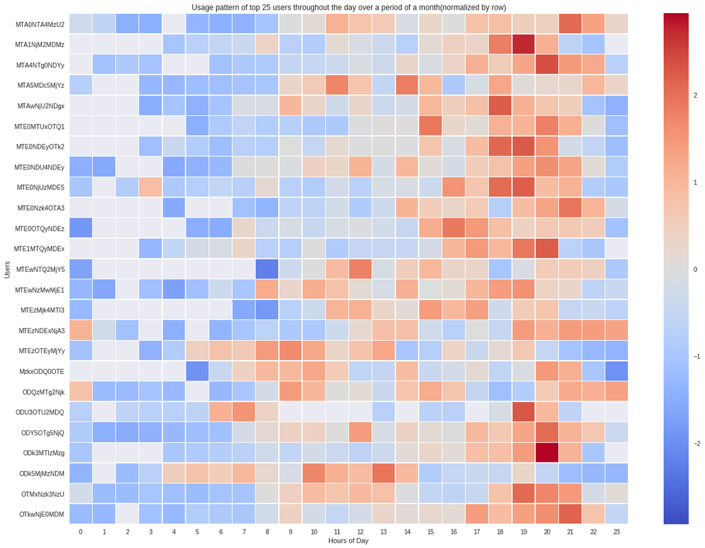

Now lets take a look at how the top 25 users use the top 25 gifs, I have ignored the gif with riffid 0 as the usage is too high and hence would distort the data. We see that there is no one clear gif(in top 25 gifs used) which is the winner as each user uses some different set of gifs. With this data we can build a personalized recommendation system of gifs for user if we have more information on gif data.

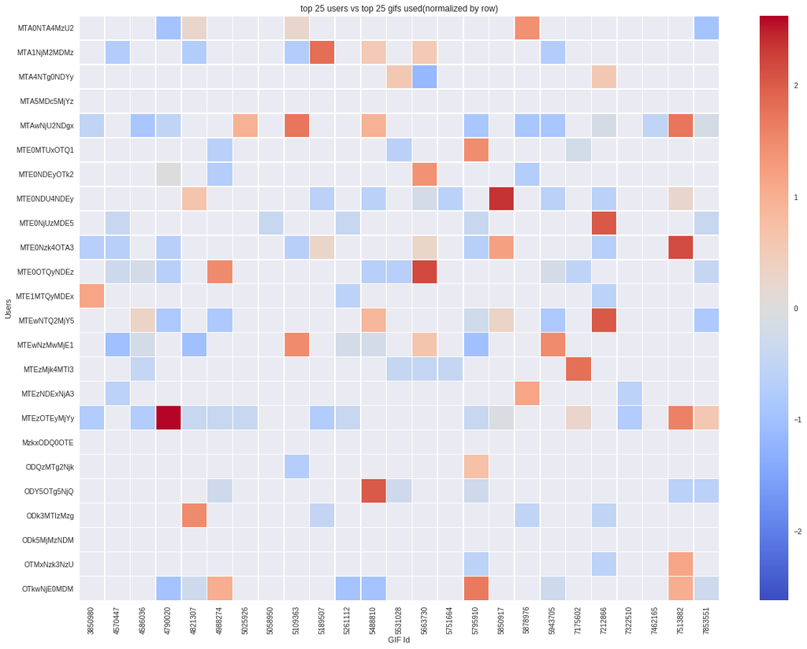

### 2. Advanced metrics

#### 2.1. Calculate difference between time stamps and start of new session

The first step would be to find the difference between two successive timestamps this can be done using the window function LAG in SQL hence we can get the difference between two successive timestamps lets call this as diff it is in seconds.

We can use this difference in timestamp to find the start of new session lets say if the time of inactivity is greater than 30 seconds we say it is a new session and also when last timestamp is null i.e start of first session for user. I created a table sessions which has all this information using the following query

```
create table sessions as
    select *,
        extract(epoch from timestamp) - extract(epoch from last_timestamp) as diff,
        case when
          extract(epoch from timestamp) - extract(epoch from last_timestamp) > 30
            or last_timestamp is NULL then 1
          else 0
        end
    from
      (select *,
        lag(timestamp) over (partition by keyboardid order by timestamp) as last_timestamp
       from ios_events)
;
```

#### 2.2. Assign Session number

We have a column in the session table which indicates 1 if it is a start of session else it is 0 so we have to number the sessions to do group operations later on. I take the cumulative sum of the new_session column using windows function which gives a global number to each session and save the results to user_sessions table by using the following query.

```
create table user_sessions as
  select *,
    sum(new_session) over (order by keyboardid, timestamp rows unbounded preceding) as session_id
  from sessions
  order by keyboardid,
    session_id
;
```

#### 2.3. Calculate average duration of a search session

```
select avg(cast(session_times AS DECIMAL(10,2))) --function avg does not return float values
from
  (select sum(diff) as session_times
  from user_sessions
  group by session_id)
;
```

The result of the query is as follows

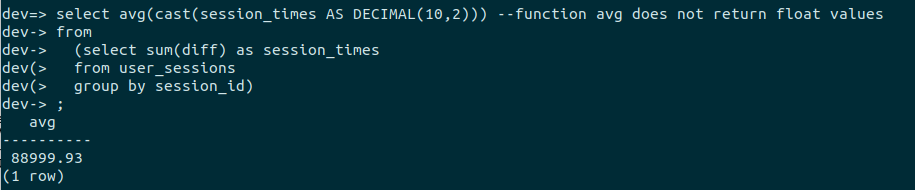

#### 2.4. Calculate share rate for each session[BONUS]

To calculate share rate for each session first of all we need to get the count of shares and searches for each session it can be done by counting records from user_sessions table by grouping the session_id.  
Then we combine the search and share table using full outer join as there are some records which are null either of the table. After getting all this I create a session_share_rates table which contain session_id, search_count, share_count and share_rate which is obtained by dividing share_count by search_count.

```
create table session_share_rates as
  select session_id,
      isnull(search_count,0) as search_count,
      isnull(share_count,0) as share_count,
      isnull(share_rate,0) as share_rate
  from
    (select COALESCE(search.session_id, share.session_id) as session_id,
      search_count, share_count,
      share_count/search_count ::float as share_rate
  from
    (select session_id, isnull(count(*),0) as search_count
    from user_sessions
    where eventname = 'textsearch'
    group by session_id) search

  full outer join

    (select session_id, isnull(count(*),0) as share_count
    from user_sessions
    where eventname = 'share'
    group by session_id) share
  on share.session_id = search.session_id)
;
```

I update session_share_rate as -1 if the search_count is 0(as division by 0 is undefined) as there are some sessions where gifs are shared directly and there are no search requests in that session.

```
update session_share_rates
  set share_rate = -1
  where search_count = 0
;
```

The result of the following query is

```
select * from session_share_rates limit 10;
```

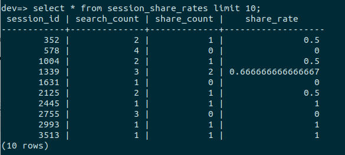

### 3. Experimental design

Suppose I have built a new model for the search engine and I want to test how effective that model is compared to the older one.

#### 3.1. Measure the effectiveness of the new model

First I would decide on the metric to optimize(KPI- key performance indicator) lets say I will use the Share rate i.e ratio of share to searches as my metric, as the share to search ratio will indicate what percentage of my searches result into share. So at the end the share rate of my model should be better than the older model(discussed more later)

#### 3.2. Additional data would you need in the dataset to compare the effectiveness of the new vs. current models?

I would require some user information like age, sex, duration the person is using Tenor, geographic location, etc. as I would use both my search engines the old and the new one simultaneously and randomly route some users to the old and new search engines I would try to set a balance in the users of old and new search engines. for eg: will let equal number of users from the same group to use both the search engines.

hence If I get demographics I can keep a balance of users using the search engines and thus avoiding bias.

#### 3.3. Determining the statistical significance of the results?

First of all I put forward my hypothesis and say that the new engine is better than the old one and treat this as null hypothesis.

So after performing the A/B test for some time interval I will treat this as a sample from the population, I will take multiple such samples and do the significance testing and get the p values and confidence intervals so that I know that the samples which I have used is as per the population.

I decide on the significance level of the test and if my P-value is greater than the significance level I say that my hypothesis is true. I will take the 95% confidence Interval and and check if the test statistic occurs in my 95%, if yes I can conclude that this experiment is true 95% of the times.

### 4. Models for finding relevant search terms

#### 4.1. A Graph based crude search model(Using Available Data)

- We can create a weighted graph of search tags where each tag is a node.
- We count the number of times the same Gif has been appeared when the two terms were searched and this count is the weight of the edge between the two nodes.
- So whenever we search a term we can get the most closest n neighbours and then suggest them as the relevant search tags for the given tag.

#### 4.2. Capturing semantic similarity(Using NLP techniques)

But in reality we need to get the semantic similarity between two search tags.

We can further improve this search term suggestion model by improving it. we can compare two search tags using following methods So basically there are 3 possible comparisons:  
1. Word vs Word  
2. group of words vs group of words  
3. Word vs group of words

##### 4.2.1. Word vs Word

##### 4.2.1.a. Word2Vec

We can use word embedding like word2vec by Google, It takes a text corpus and outputs word vectors. Using word2vec in Gensim a python library we can get cosine similarity of two words and then compare the other words and get the most relevant words.  
There are some known problems in Word2vec, it would give a higher similarity if the two words have the similar context for eg: hot and cold will have a similar context for the sentence “The weather today is ..”, The dots can be filled with both hot and cold. So in this case the vectors for hot and cold would be more closer.

##### 4.2.1.b. Using WordNet

It is a large lexical database of English words, these words are grouped into a set of cognitive synonyms called as synsets which are interlinked by means of semantic and lexical relations.

There are many different word embedding techniques like spaCy, GloVe, Latent semantic embedding etc but each of them has some sort of limitations, We can combine all this results and form an ensemble which works well for the problem.

##### 4.2.2. Group of words vs Group of words

While finding similarities in queries we need to find the semantic similarity between them and not just the word similarity. We can divide this problem into Supervised and an Unsupervised problem

###### 4.2.2.A. Unsupervised methods:

1. Using sentence vector:  
   we can use word2Vec model or any sort of word embedding to form the vector of each of the search query present in our database. We can combine this word vectors of each word to form a vector of each sentence and then we can use cosine similarity or any other distance metric to get the similarity and difference between each search query and then we can suggested the most relevant query for the current query based on distance
2. Semantic similarity of words:
   Break the group of words into individual words and identify the word similarity for all combinations of Verb-Verb pairs with higher weights that that of Noun-Noun pairs. Then find the final value of semantic similarity between the sentences by averaging of all these pair’s word similarity using synsets in wordnet.
   $$Final Score = Avg(\alpha \sum VerbScore + \beta \sum NounScore )$$
   here $\alpha$ and $\beta$ can be adjusted for maximum accuracy.
3. Using Topic Modeling:  
   We can find relevant Topics in group of words using LDA or other topic modeling techniques and then compare this topics with the topics of other relevant query

###### 4.2.2.B. Supervised Methods:

If we have a dataset which already has labeled corpus of similar and non similar queries then we can use Machine Learning algorithms to learn the dependencies on the vectors of query which we can form by any of the embedding techniques or use Convolution neural network to build the vector of the query.

##### 4.2.3. Word vs group of words

##### a. Using Embeddings

One approach to deal with this problem is use similarity measure on word vector and group of words vector together and then apply similarity measures(Unsupervised) or Machine Learning Models(supervised).

##### b. Topic Modeling for group of words:

Find relevant topics for the group of words and and then compare this topics with the word in other query and find the similarity using wordnet.

Thus at the end we need to combine all these models to find the similarity between two search tags and then make the relevant suggestions based on the similarity with other.